# Fluvial meta-ecosystem modelling

Matthew Talluto

10/02/2020

## A simple (single-species) metapopulation model

$$\frac{\partial p}{\partial t} = cp \left( h-p \right) - pm$$

This model is non-spatial, assumes infinite dispersal, and all patches are identical in quality.

- $p$: number of occupied patches
- $c$: colonisation rate
- $h$: number of available patches
- $m$: extinction rate

## A simple (single-species) metapopulation model

$$\frac{\partial p}{\partial t} = cp \left( h-p \right) - pm$$

This model is non-spatial, assumes infinite dispersal, and no (or identical) niches.

- $cp$: colonisation depends on prevalence; more occupancy means more propagules, faster colonisation
- $h-p$: only unoccupied patches can be colonised
- $pm$: only occupied patches can experience extinction

## Extending to metacommunities

- For species $i$ competing with a second species $j$

$$\frac{\partial p_i}{\partial t} = c_i p_i \left( h-p_i \right) - p_i \left( m_{ij}p_j + m_i \right)$$

**Extending to multiple species**

For $S$ species in a metacommunity (and where $S \setminus \left\{i \right\}$ is the set of species excluding i):

$$\frac{\partial p_i}{\partial t} = c_i p_i \left( h-p_i \right) - p_i \left( \sum_{j \in S \setminus \left\{i \right\} }{m_{ij}p_j} + m_i \right)$$

Hunt, Julia J. F. G., and Michael B. Bonsall. The Effects of Colonization, Extinction and Competition on Co-Existence in Metacommunities. Journal of Animal Ecology, vol. 78, no. 4, 2009, pp. 866–879

## Making the model spatial

$$\frac{\partial N}{\partial t} = Nc \left( H-N \right) - mN$$

We define the state of patch $y$ at time $t$ by a state vector ${\mathrm{\mathbf{X_{y,t}}}} \in \{ 0, 1 \}$.

It can take two states, occupied and unoccupied.

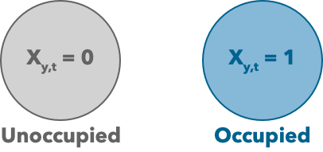

## Transition rates

$$\frac{\partial N}{\partial t} = Nc \left( H-N \right) - mN$$

- Unoccupied patches become occupied at the rate $Nc$,
- Occupied patches go extinct at rate $m$.
- To make this rate local, use $N_y$, the number of patches neighbouring patch $y$ that are occupied.

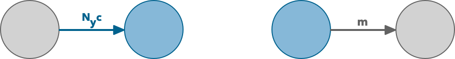

## More realistic dispersal

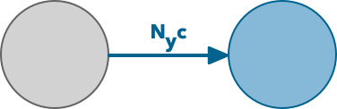

- In a river, we can further incorporate and active and a passive component to dispersal by splitting apart the colonisation rate $c$:

$$c = {\mathrm{\mathbf{Q_y}}} \alpha + \beta$$

- ${\mathrm{\mathbf{N_y}}}$: vector of presence-absence in all patches that are neighbours of patch $y$
- ${\mathrm{\mathbf{Q_y}}}$: vector of discharge *into* the patch from neighbours (0 for downstream patches)
- $\alpha$: passive dispersal ability of the species
- $\beta$: active dispersal ability of the species.
- This gives a colonisation rate $= {\mathrm{\mathbf{N_y}}} \left( {\mathrm{\mathbf{Q_y}}} \alpha + \beta \right)$

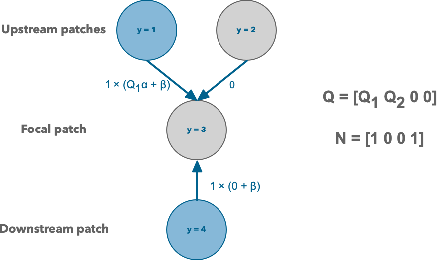

## Adding niches

- So far the model is neutral; there is no difference in patch quality
- Species in nature can exploit resources with differing abilities

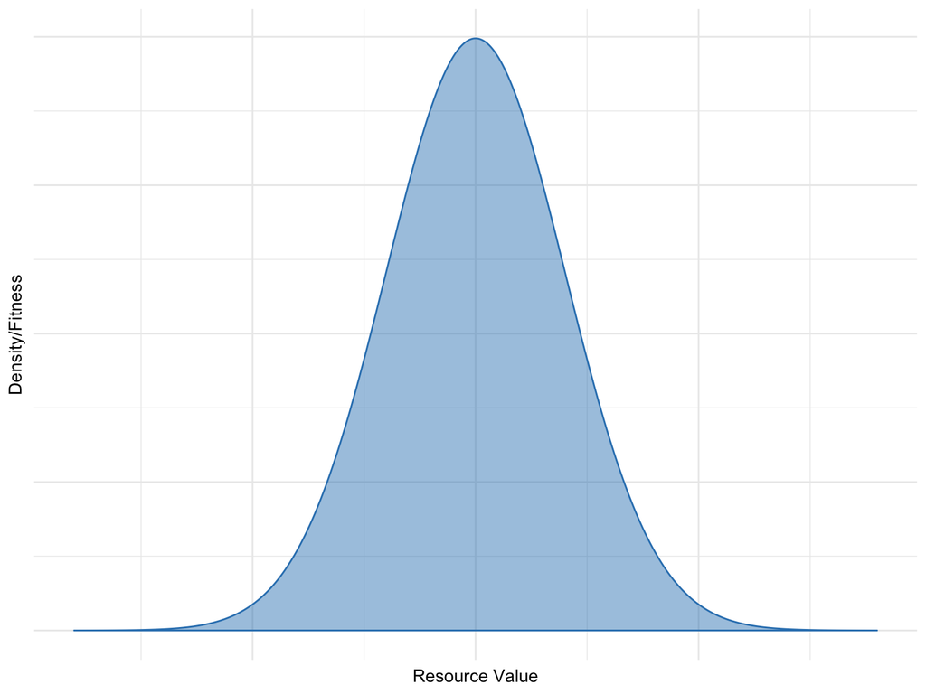

## Adding niches

- Patches likewise can be expected to have a distribution of resources

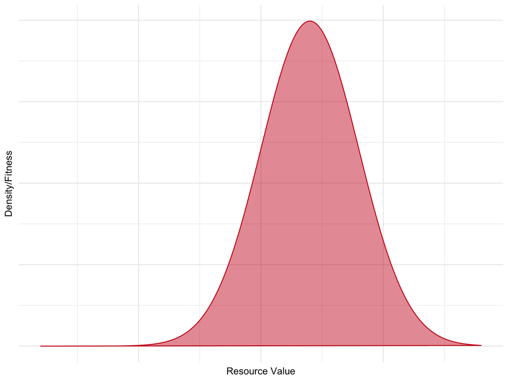

## Adding niches

- A given target species will have some available resources it can use better than others

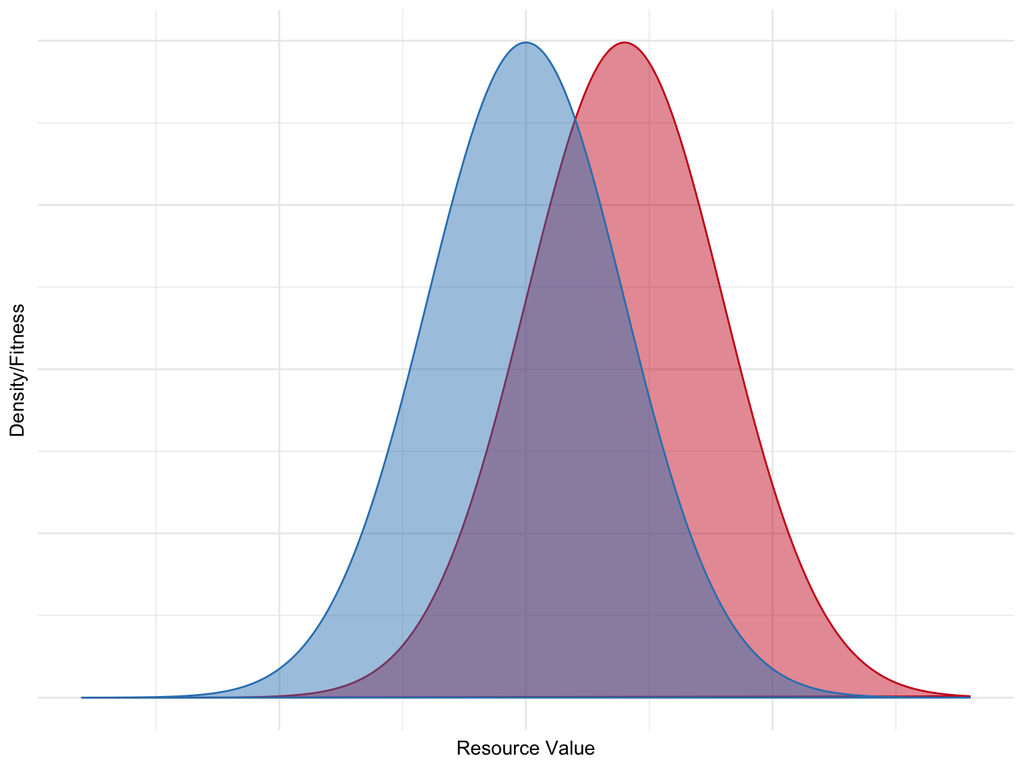

## Adding niches

- The area of overlap is the fitness of the species in the patch ($\omega_y$).

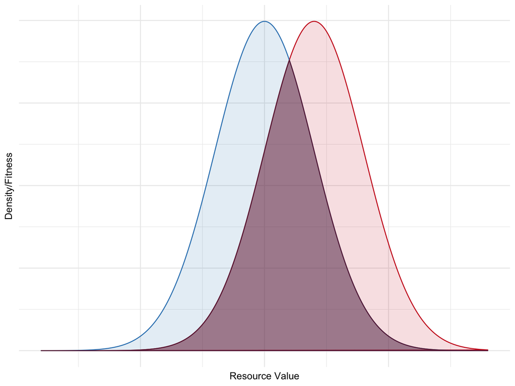

- We add this as a patch quality term to the colonisation rate:

$$c = \omega_y \left( {\mathrm{\mathbf{Q_y}}} \alpha + \beta \right)$$

## Competition

- So far, we have a metapopulation model
- To make a metacommunity model, we consider multiple species, each with distinct niches

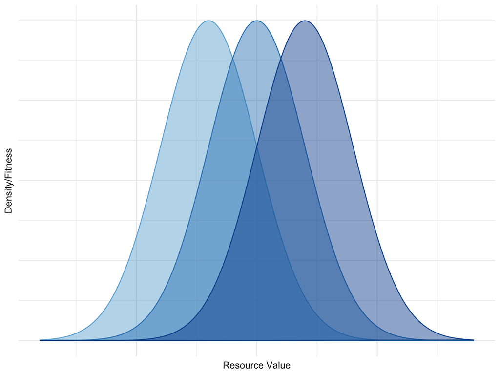

## Competition

- For a focal species $i$ with fitness $\omega_{y,i}$

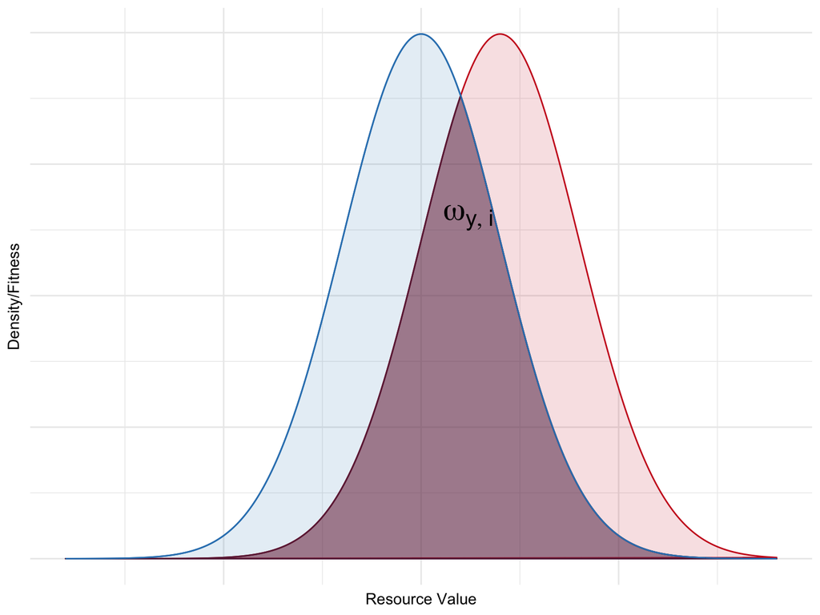

## Competition

- For a focal species $i$ with fitness $\omega_{y,i}$

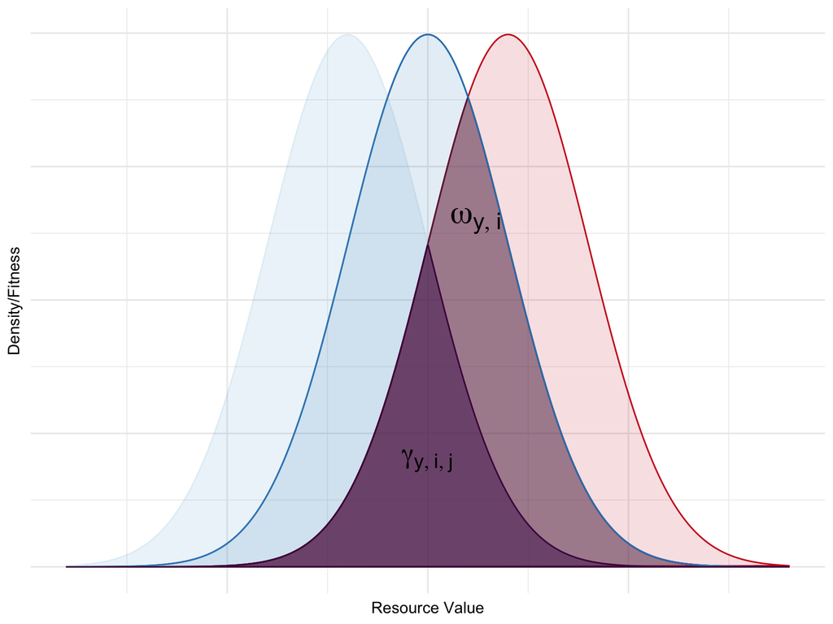

- Adding a species will result in some resources ($\gamma_{y,i,j}$) coming under competition
- The ratio $\frac{\gamma_{y,i,j}}{\omega_{y,i}}$ is the relative strength of competition

## Competition

if $\omega_i$ is the overlap of the niche of species $i$ with the resources in a patch, and $\gamma_{i,j}$ is the overlap of the niches of both $i$ and $j$ with the resources of a patch, then $\frac{\gamma_{i,j}}{\omega_i}$ is a simple model for the strength of competition; the proportion of resources that are in competition with the two species.

Can extend this to all species, either by summing (in which case the sums of all overlaps could be much greater than 1), or by taking just the overlap with any species